# New York City - Green Taxis Data Analysis

Vaishnavi Srinivasan

January 20, 2018

I am analyzing the data from New York City Taxi and Limousine commission for Green Taxis. The green taxis are not allowed to pick up passengers inside of the densely populated areas of Manhattan.

I will be analyzing the September 2015 data set, available from below link: http://www.nyc.gov/html/tlc/html/about/trip_record_data.shtml.

Data dictionary: http://www.nyc.gov/html/tlc/downloads/pdf/data_dictionary_trip_records_green.pdf Rate information: http://www.nyc.gov/html/tlc/html/passenger/taxicab_rate.shtml

I will be using R for data analysis and visualization.

I will also be submitting the nyc_taxi.rmd markdown file, when knit can be used to reproduce the results, includes the r-code, its output and my write-up

As a first step, all the necessary libraries are downloaded and loaded to memory.

# Question 1 - Loading Data

To begin the analysis, I will be loading the file in R. If the file is not available in current location, it will be downloaded from https://s3.amazonaws.com/nyc-tlc/trip+data/green_tripdata_2015-09.csv and loaded.

The number of rows, columns and summary statistics per feature of the green taxis trip data is displayed.

```
## [1] Loading the file..
```

```
##
##
## Number of rows in the file:  1494926
```

```
##
##
## Number of columns in the file:  21
```

```
##
##
## Summary of the green taxi NYC data:
```

```
##     VendorID              lpep_pickup_datetime
##  Min.   :1.000   2015-09-20 02:00:32:      9
##  1st Qu.:2.000   2015-09-05 14:57:48:      8
##  Median :2.000   2015-09-10 17:43:49:      8
##  Mean   :1.782   2015-09-13 00:27:28:      8
##  3rd Qu.:2.000   2015-09-13 01:06:29:      8
##  Max.   :2.000   2015-09-26 22:48:40:      8
##                  (Other)            :1494877
##          Lpep_dropoff_datetime Store_and_fwd_flag   RateCodeID
##  2015-09-28 00:00:00:    172   N:1486192          Min.   : 1.000
##  2015-09-13 00:00:00:    153   Y:   8734          1st Qu.: 1.000
##  2015-09-19 00:00:00:    141                      Median : 1.000
##  2015-09-14 00:00:00:    126                      Mean   : 1.098
##  2015-09-21 00:00:00:    125                      3rd Qu.: 1.000
##  2015-09-12 00:00:00:    119                      Max.   :99.000
##  (Other)            :1494090
##  Pickup_longitude Pickup_latitude Dropoff_longitude Dropoff_latitude
##  Min.   :-83.32   Min.   : 0.00   Min.   :-83.43    Min.   : 0.00
##  1st Qu.:-73.96   1st Qu.:40.70   1st Qu.:-73.97    1st Qu.:40.70
##  Median :-73.95   Median :40.75   Median :-73.95    Median :40.75
##  Mean   :-73.83   Mean   :40.69   Mean   :-73.84    Mean   :40.69
##  3rd Qu.:-73.92   3rd Qu.:40.80   3rd Qu.:-73.91    3rd Qu.:40.79
##  Max.   :  0.00   Max.   :43.18   Max.   :  0.00    Max.   :42.80
##
##  Passenger_count Trip_distance      Fare_amount          Extra
##  Min.   :0.000   Min.   :  0.000   Min.   :-475.00   Min.   :-1.0000
##  1st Qu.:1.000   1st Qu.:  1.100   1st Qu.:   6.50   1st Qu.: 0.0000
##  Median :1.000   Median :  1.980   Median :   9.50   Median : 0.5000
##  Mean   :1.371   Mean   :  2.968   Mean   :  12.54   Mean   : 0.3513
##  3rd Qu.:1.000   3rd Qu.:  3.740   3rd Qu.:  15.50   3rd Qu.: 0.5000
##  Max.   :9.000   Max.   :603.100   Max.   : 580.50   Max.   :12.0000
##
##     MTA_tax          Tip_amount       Tolls_amount      Ehail_fee
##  Min.   :-0.5000   Min.   :-50.000   Min.   :-15.2900   Mode:logical
##  1st Qu.: 0.5000   1st Qu.:  0.000   1st Qu.:  0.0000   NA's:1494926
##  Median : 0.5000   Median :  0.000   Median :  0.0000
##  Mean   : 0.4866   Mean   :  1.236   Mean   :  0.1231
##  3rd Qu.: 0.5000   3rd Qu.:  2.000   3rd Qu.:  0.0000
##  Max.   : 0.5000   Max.   :300.000   Max.   : 95.7500
##
##  improvement_surcharge  Total_amount      Payment_type     Trip_type
##  Min.   :-0.3000       Min.   :-475.00   Min.   :1.000   Min.   :1.000
##  1st Qu.: 0.3000       1st Qu.:   8.16   1st Qu.:1.000   1st Qu.:1.000
##  Median : 0.3000       Median :  11.76   Median :2.000   Median :1.000
##  Mean   : 0.2921       Mean   :  15.03   Mean   :1.541   Mean   :1.022
##  3rd Qu.: 0.3000       3rd Qu.:  18.30   3rd Qu.:2.000   3rd Qu.:1.000
##  Max.   : 0.3000       Max.   : 581.30   Max.   :5.000   Max.   :2.000
##                                                          NA's   :4
```

# Question 2 - Histogram & Structure

The distribution of trip distance is analyzed using a histogram.

```
## [1] 0
```

```
## [1] 603.1
```

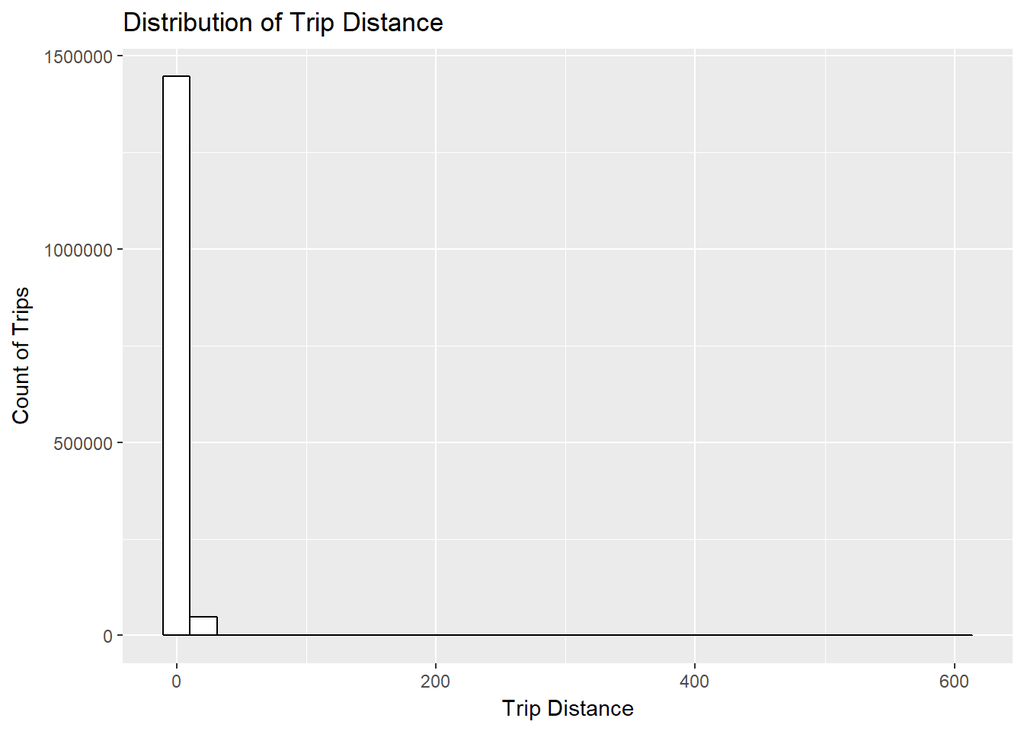

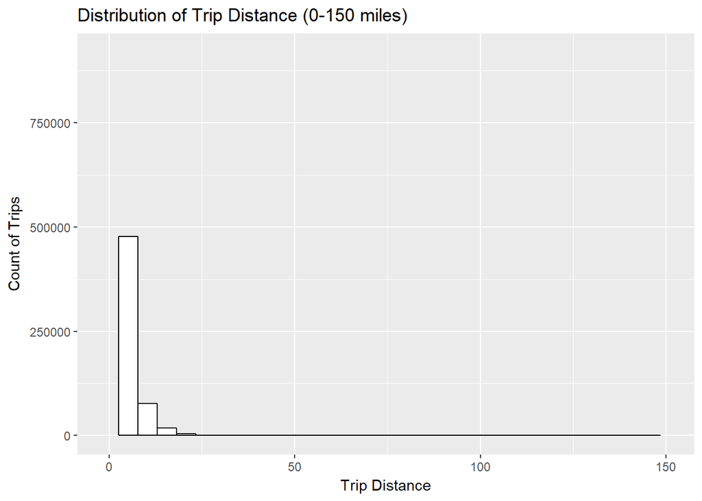

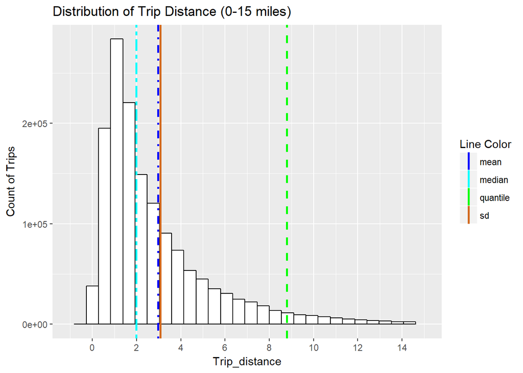

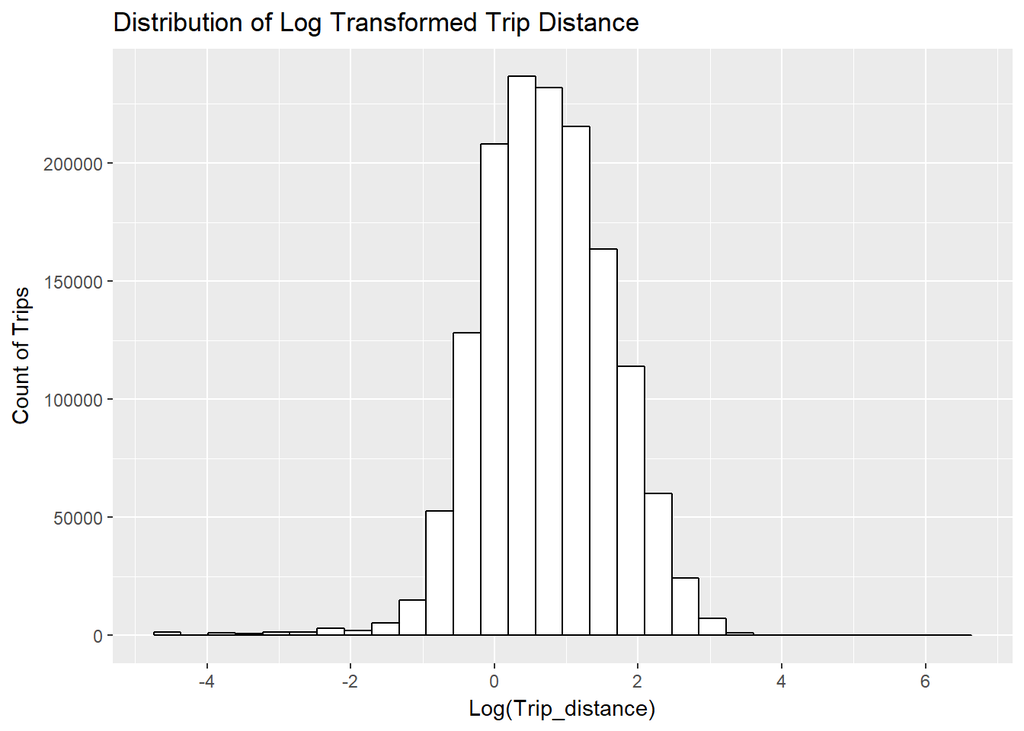

From the histogram of the complete trip distance, I found the most of the data clustered around 0 to 150 miles. But, due to the presence of outliers we are not able to view the complete distribution. Zooming in on trip distance, between 0 and 150 miles, I find the data to be distributed within 15 miles.

Limiting the trip distance to 15 miles and plotting the mean, median, standard deviation and quantiles, I find the distribution asymmetric and positively skewed. The structure of the distribution is lognormal (http://people.stern.nyu.edu/adamodar/New_Home_Page/StatFile/statdistns.htm - Figure 6A.9: Lognormal distribution). It’s standard deviation is 3.07 miles, which is higher than mean (2.96 miles) and the median (1.98 miles). From the 95th quantile, I found 95% of trip distance to be within 8.8 miles.

# Question 3 - Mean & Median by group

For the next part of my analysis, I will be looking at the trip distance grouped by the hour of day.

**Assumptions:** The pickUp_datetime feature contains the date and time a passenger boarded the taxi and will be used for for calculating the hour of day. As we are not considering the travel time, dropOff_datetime will not be considered for calculating the hour of day.

```
##
##
##  Median Trip Distance by Pick-up hour is:
```

| pickUpHour | Trip_distance |
| --- | --- |
| 0 | 2.20 |
| 1 | 2.12 |
| 2 | 2.14 |
| 3 | 2.20 |
| 4 | 2.36 |
| 5 | 2.90 |
| 6 | 2.84 |
| 7 | 2.17 |
| 8 | 1.98 |
| 9 | 1.96 |

[output cut: 14 more lines]

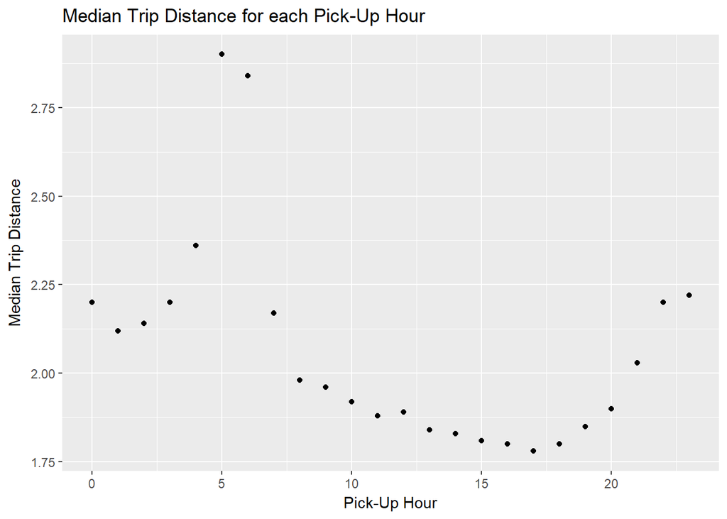

```
##
##
##  Mean Trip Distance by Pick-up hour is:
```

| pickUpHour | Trip_distance |
| --- | --- |
| 0 | 3.115276 |
| 1 | 3.017347 |
| 2 | 3.046176 |
| 3 | 3.212945 |
| 4 | 3.526555 |
| 5 | 4.133474 |
| 6 | 4.055149 |
| 7 | 3.284394 |
| 8 | 3.048450 |
| 9 | 2.999105 |

[output cut: 14 more lines]

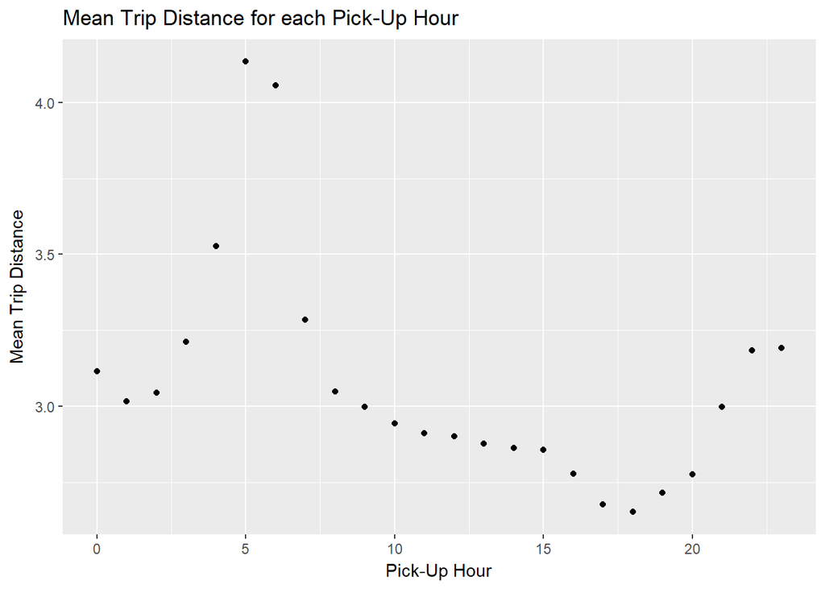

Plotting the mean and median of the trip distance grouping by hour, I find that people tend to travel during the peak hours - early morning between 5:00 AM to 8:00 AM and at night after 8:00 PM.

**My hypothesis** Passengers tend to travel more distance at the early hour peak - say, rushing to catch flights or going to work (early shift or a presentation and don’t want to be late), and at night after 8:00 PM - say, after working late hours at office. Based on the http://www.businessinsider.com/heres-why-new-york-city-air-traffic-is-so-congested-2015-7, travelers at NYC consider the best time to fly out at early mornings (6:00 AM) which justifies the peak at around 5:00 AM for long distance commute (distance between NYC and Newark is 20 miles).

# Question 3 - Airport trip report

Now I will be looking at the characteristics of the trips originating and terminating at the airports.

**Assumptions**

- Newark airport is generally considered as NYC airport (all google searches yielded this) even though it is in New Jersey
- http://www.nyc.gov/html/tlc/html/passenger/taxicab_rate.shtml - taxi cabs having a RateCodeID of ‘02’ and ‘03’ have pick-up or drop-off points at JFK and Newark airport respectively
- Got the co-ordinates of Newark, LaGuardia and JFK airports using google and derived a boundary (given below) that covers the area around these airports

JFK Airport:  
Minimum Latitude is 40.63  
Maximum Latitude is 40.65  
Minimum Longitude is -73.82  
Maximum Longitude is -73.75

LaGuardia Airport:  
Minimum Latitude is 40.76  
Maximum Latitude is 40.78  
Minimum Longitude is -73.89  
Maximum Longitude is -73.85

Newark Airport:  
Minimum Latitude is 40.67  
Maximum Latitude is 40.71  
Minimum Longitude is -74.19  
Maximum Longitude is -74.15

Initially, I specified the bounding co-ordinates of the airports for analysis and found the data points to be very less. Looking at the data dictionary (http://www.nyc.gov/html/tlc/downloads/pdf/data_dictionary_trip_records_green.pdf), I found the rate code id to be a good indicator for identifying trips that originated or terminated at one of the NYC area airports. Finally, I merged the data from rate code id and co-ordinates to derive the final value.

```
##
##
## Number of Transactions that originate or terminate at
##     one of the NYC area airports (only latitude & longitude):  372
```

```
##
##
## Average fair amount that originate or terminate at
##     one of the NYC area airports per trip (only latitude & longitude): $ 32.56546
```

```
##
##
## Number of Transactions that originate or terminate at one of the NYC area airports
##     (only rate code id):  5552
```

```
##
##
## Average fair amount that originate or terminate at one of the NYC area airports per
##     trip (only rate code id): $ 48.97695
```

```
##
##
## Number of Transactions that originate or terminate at
##     one of the NYC area airports (latitude, longitude and rate code id):  5897
```

```
##
##
## Average fair amount that originate or terminate at
##     one of the NYC area airports per trip (latitude, longitude and rate code id): $ 47.8928
```

Other important characteristics considered are:

- Distribution of Trip Duration
- Distribution of Trip Distance
- Distribution of Trip Pick-up hour

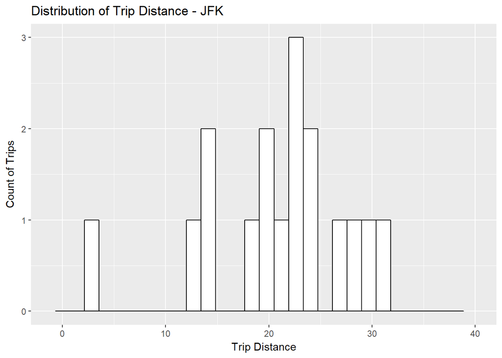

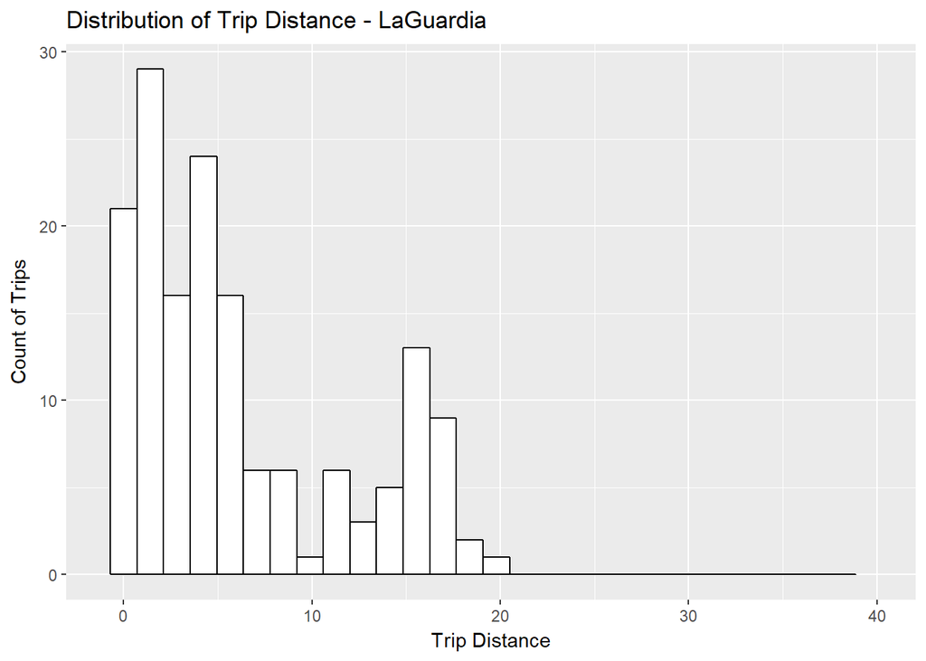

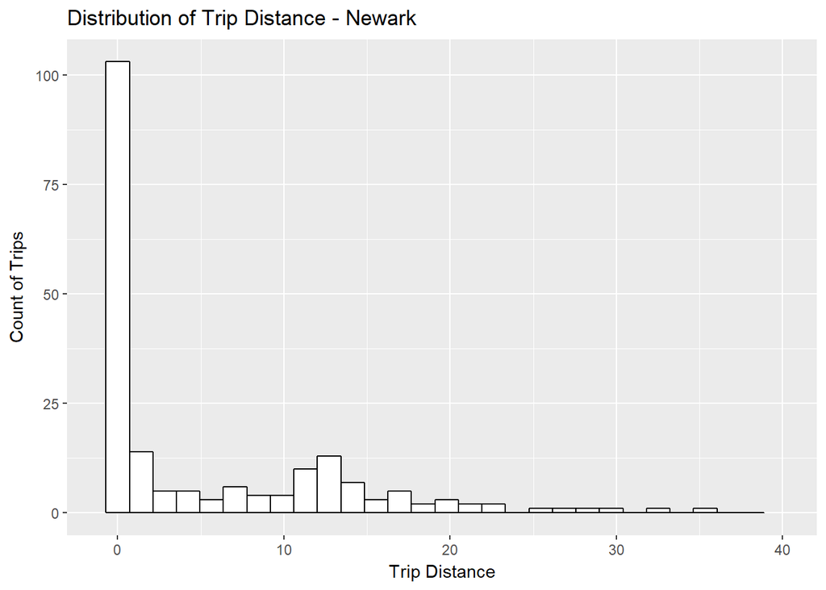

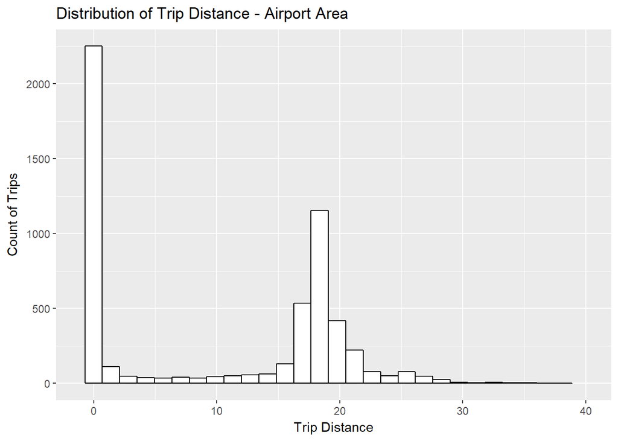

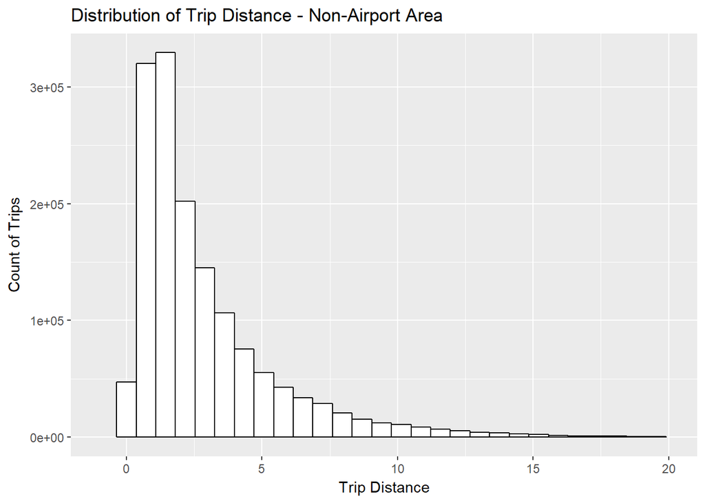

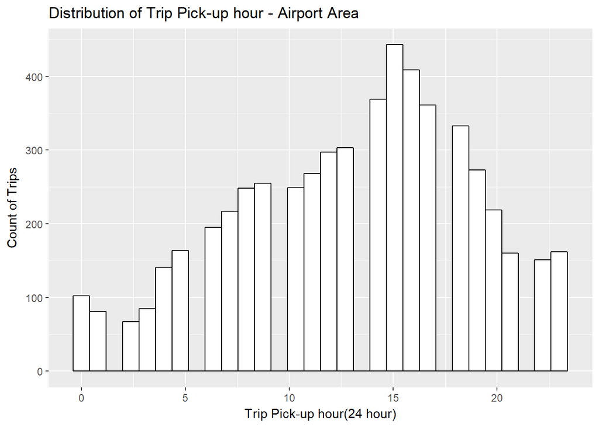

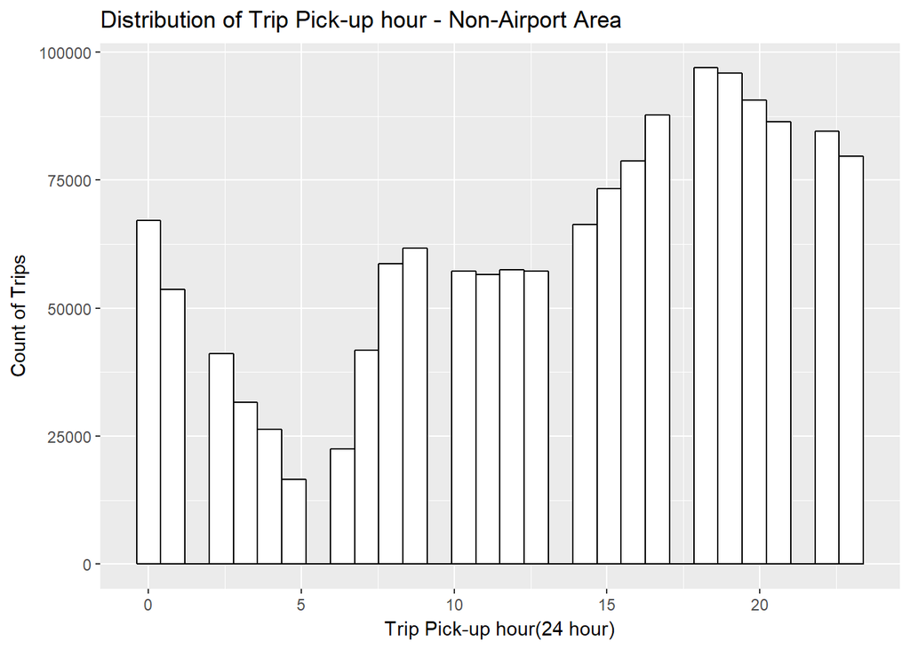

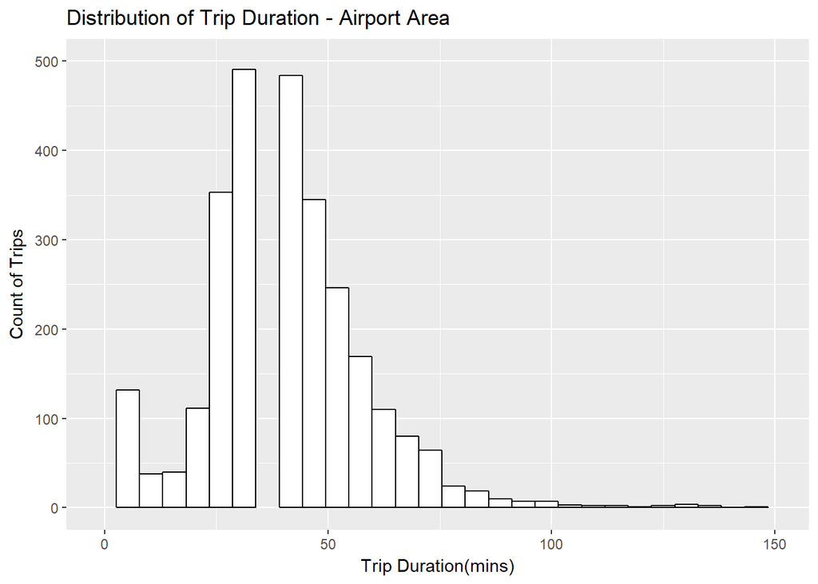

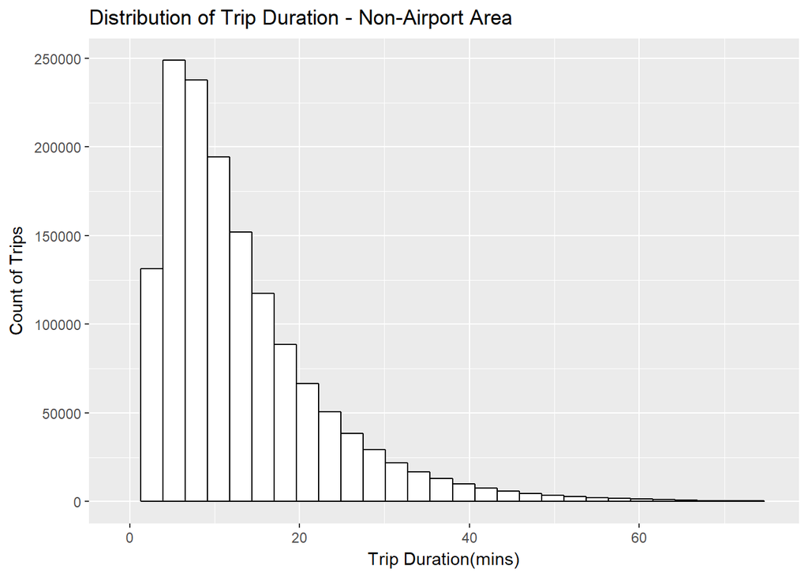

# Question 4 - Tip Percent

Now I will analyze the derived variable - tip percent, tip amount as a percentage of the total fare amount.

Summarizing the tip percentage, we find 4172 records having ‘NA’ as their tip percentage.

Decoding further, I found the presence of a data points having the total amount as a negative value (with 0 tip) and 0.

Looking at the NYC taxi minimum fare amount from http://nymag.com/nymetro/urban/features/taxi/n_20286/ & http://www.nyc.gov/html/tlc/html/passenger/taxicab_rate.shtml - I found an initial charge of $2.00 charged for a ride (with airports having a minimum fixed cost), which had been increased to 2.50$.

And so, I filter on the total amount that have a value either equal or more than the initial charge.

```
##    Min. 1st Qu.  Median    Mean 3rd Qu.    Max.    NA's
##   0.000   0.000   0.000   6.654  16.667 100.000    4172
```

```
##    Min. 1st Qu.  Median    Mean 3rd Qu.    Max.
##   0.000   0.000   0.000   6.666  16.667 100.000
```

```
## [1] 1487889
```

```
## [1] 6.665601
```

```
## [1] 8.876661
```

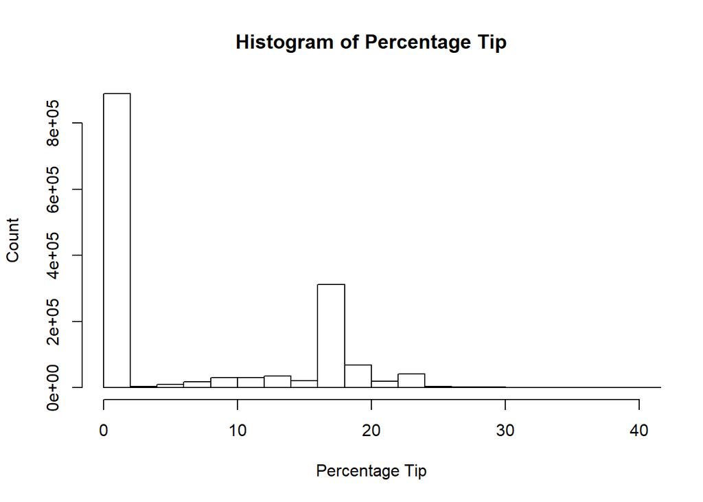

# Question 4 - Predictive Model

Now I begin building the predictive model for tip percentage.

As the first step, I will start performing data cleansing.

Displaying the statistical information of green taxis data -

|  | VendorID | lpep_pickup_datetime | Lpep_dropoff_datetime | Store_and_fwd_flag | RateCodeID | Pickup_longitude | Pickup_latitude | Dropoff_longitude | Dropoff_latitude | Passenger_count | Trip_distance | Fare_amount | Extra | MTA_tax | Tip_amount | Tolls_amount | Ehail_fee | improvement_surcharge | Total_amount | Payment_type | Trip_type | percTip |
| --- | --- | --- | --- | --- | --- | --- | --- | --- | --- | --- | --- | --- | --- | --- | --- | --- | --- | --- | --- | --- | --- | --- |
| nbr.val | 1.494926e+06 | NA | NA | NA | 1.494926e+06 | 1.494926e+06 | 1.494926e+06 | 1.494926e+06 | 1.494926e+06 | 1.494926e+06 | 1.494926e+06 | 1.494926e+06 | 1.494926e+06 | 1.494926e+06 | 1.494926e+06 | 1.494926e+06 | NA | 1.494926e+06 | 1.494926e+06 | 1.494926e+06 | 1.494922e+06 | 1.490754e+06 |
| nbr.null | 0.000000e+00 | NA | NA | NA | 0.000000e+00 | 2.110000e+03 | 2.110000e+03 | 1.963000e+03 | 1.963000e+03 | 4.400000e+02 | 2.059200e+04 | 4.468000e+03 | 6.845240e+05 | 3.556800e+04 | 8.921560e+05 | 1.463043e+06 | NA | 3.494100e+04 | 4.172000e+03 | 0.000000e+00 | 0.000000e+00 | 8.879840e+05 |
| nbr.na | 0.000000e+00 | NA | NA | NA | 0.000000e+00 | 0.000000e+00 | 0.000000e+00 | 0.000000e+00 | 0.000000e+00 | 0.000000e+00 | 0.000000e+00 | 0.000000e+00 | 0.000000e+00 | 0.000000e+00 | 0.000000e+00 | 0.000000e+00 | NA | 0.000000e+00 | 0.000000e+00 | 0.000000e+00 | 4.000000e+00 | 4.172000e+03 |
| min | 1.000000e+00 | NA | NA | NA | 1.000000e+00 | -8.331908e+01 | 0.000000e+00 | -8.342784e+01 | 0.000000e+00 | 0.000000e+00 | 0.000000e+00 | -4.750000e+02 | -1.000000e+00 | -5.000000e-01 | -5.000000e+01 | -1.529000e+01 | NA | -3.000000e-01 | -4.750000e+02 | 1.000000e+00 | 1.000000e+00 | 0.000000e+00 |
| max | 2.000000e+00 | NA | NA | NA | 9.900000e+01 | 0.000000e+00 | 4.317726e+01 | 0.000000e+00 | 4.279934e+01 | 9.000000e+00 | 6.031000e+02 | 5.805000e+02 | 1.200000e+01 | 5.000000e-01 | 3.000000e+02 | 9.575000e+01 | NA | 3.000000e-01 | 5.813000e+02 | 5.000000e+00 | 2.000000e+00 | 1.000000e+02 |
| range | 1.000000e+00 | NA | NA | NA | 9.800000e+01 | 8.331908e+01 | 4.317726e+01 | 8.342784e+01 | 4.279934e+01 | 9.000000e+00 | 6.031000e+02 | 1.055500e+03 | 1.300000e+01 | 1.000000e+00 | 3.500000e+02 | 1.110400e+02 | NA | 6.000000e-01 | 1.056300e+03 | 4.000000e+00 | 1.000000e+00 | 1.000000e+02 |
| sum | 2.664025e+06 | NA | NA | NA | 1.640910e+06 | -1.103716e+08 | 6.083025e+07 | -1.103813e+08 | 6.083288e+07 | 2.048942e+06 | 4.437151e+06 | 1.875115e+07 | 5.251376e+05 | 7.274920e+05 | 1.847320e+06 | 1.840324e+05 | NA | 4.366665e+05 | 2.247195e+07 | 2.303021e+06 | 1.528338e+06 | 9.919218e+06 |
| median | 2.000000e+00 | NA | NA | NA | 1.000000e+00 | -7.394536e+01 | 4.074674e+01 | -7.394504e+01 | 4.074728e+01 | 1.000000e+00 | 1.980000e+00 | 9.500000e+00 | 5.000000e-01 | 5.000000e-01 | 0.000000e+00 | 0.000000e+00 | NA | 3.000000e-01 | 1.176000e+01 | 2.000000e+00 | 1.000000e+00 | 0.000000e+00 |
| mean | 1.782045e+00 | NA | NA | NA | 1.097653e+00 | -7.383084e+01 | 4.069114e+01 | -7.383728e+01 | 4.069291e+01 | 1.370598e+00 | 2.968141e+00 | 1.254320e+01 | 3.512800e-01 | 4.866408e-01 | 1.235727e+00 | 1.231047e-01 | NA | 2.920991e-01 | 1.503215e+01 | 1.540559e+00 | 1.022353e+00 | 6.653826e+00 |
| SE.mean | 3.376679e-04 | NA | NA | NA | 5.201263e-04 | 2.270505e-03 | 1.252079e-03 | 2.190213e-03 | 1.207763e-03 | 8.501270e-04 | 2.516310e-03 | 8.246516e-03 | 2.995977e-04 | 6.955647e-05 | 1.988658e-03 | 7.287432e-04 | NA | 4.149936e-05 | 9.449107e-03 | 4.279918e-04 | 1.209066e-04 | 7.268974e-03 |

[output cut: 4 more lines]

As we can see from the statistical information, the data for ehail_fee is all N/A, we can drop the feature from dataset.

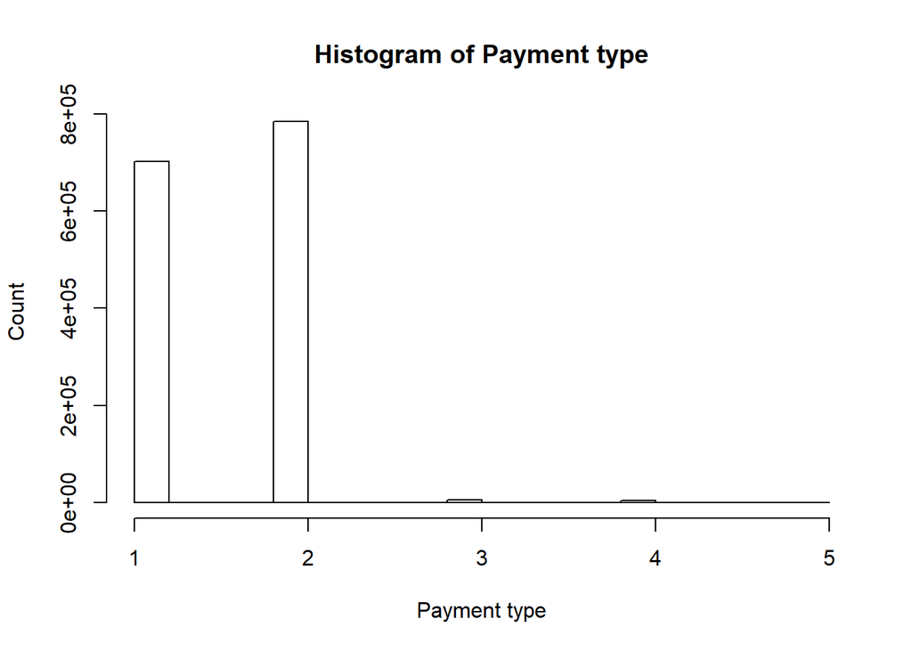

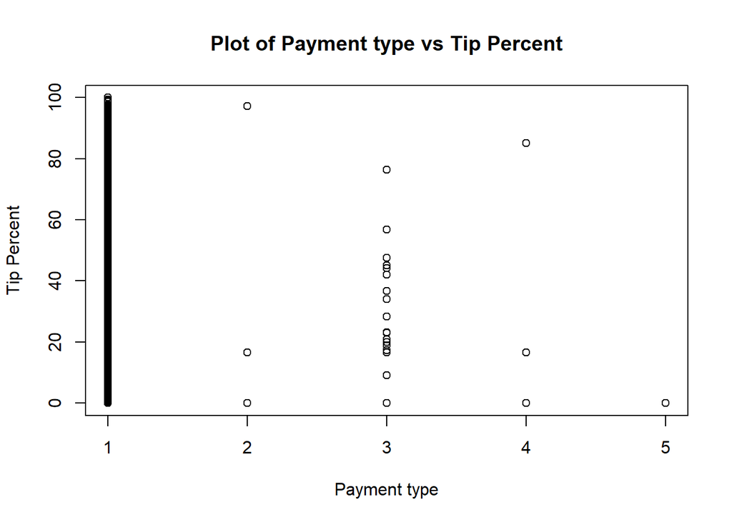

Analyzing the dataset I found approximately 40% of the transactions having a tip. Looking at the scatter plot of payment type against the tip percentage, I found more than 90% of the tip received has been from credit card.

And so, I have dropped the payment method field after filtering the data on credit card.

Next, I move on to cleansing the amount fields since the amounts cannot be negative. No additioanl information is available so as why the amount is negative, the below filters are applied:

- NYC taxi minimum fare amount from http://nymag.com/nymetro/urban/features/taxi/n_20286/ & http://www.nyc.gov/html/tlc/html/passenger/taxicab_rate.shtml - initial charge of $2.00 charged for a ride. (0.49% of data has negative amount)
- Analyzing on the Tip_amount, I found nearly 2000 records have tip amount more than the total charge (Fare_amount+Extra+MTA_tax+improvement_surcharge). These might have happened by chance (someone must have gotten lucky or it could be an outlier). These records are filtered.

After applying the above filter, I found no negative amounts in improvement_surcharge, MTA_tax, Tolls_amount and so no filters are applied on these fields.

Percentage tip is re-calculated for the new subset of data as a derivative of fare_amount, MTA_tax and improvement surcharge (I have not used the total_amount as the total_amount is inclusive of tip amount).

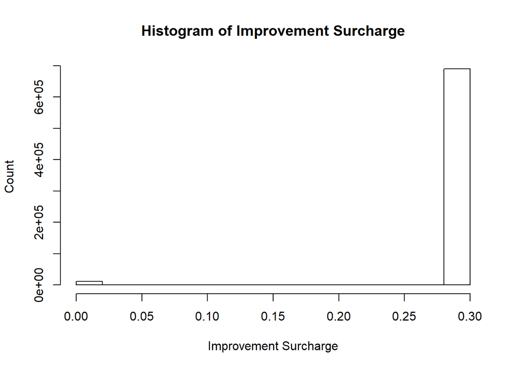

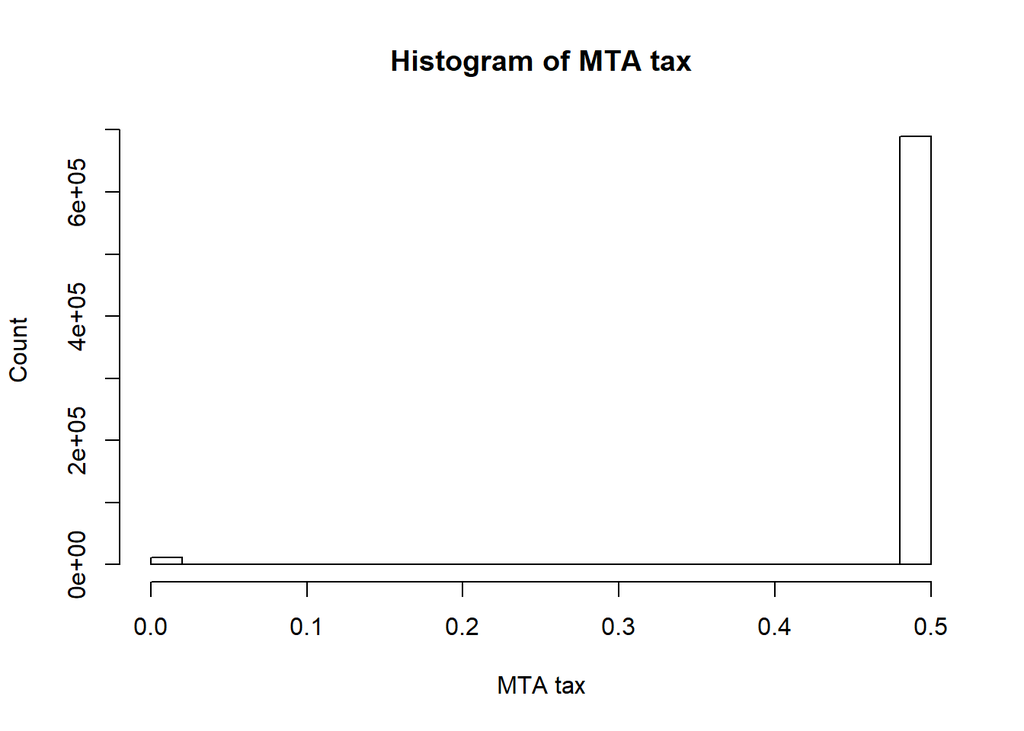

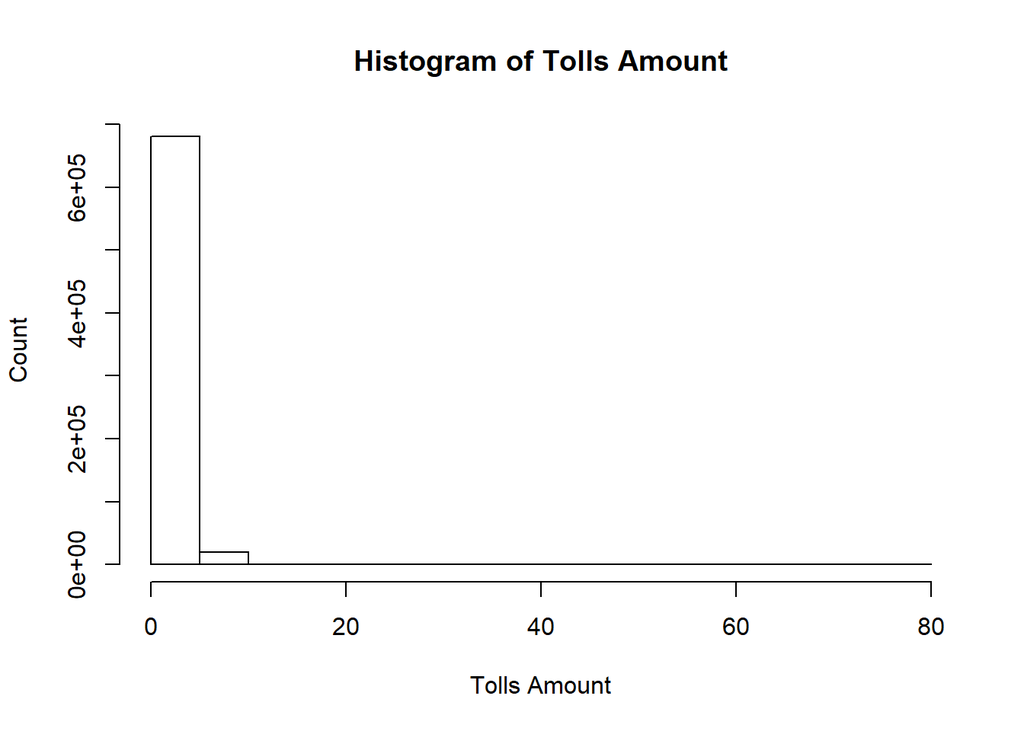

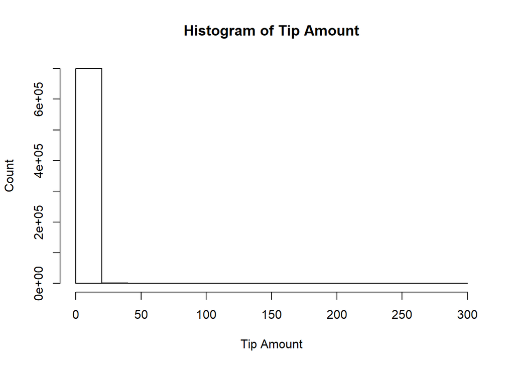

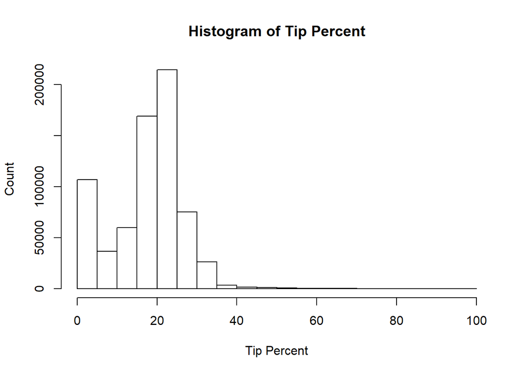

Next I move on to cleansing the rate code id, passenger count and geographic co-ordinates fields,

Records matching the above conditions are filtered out.

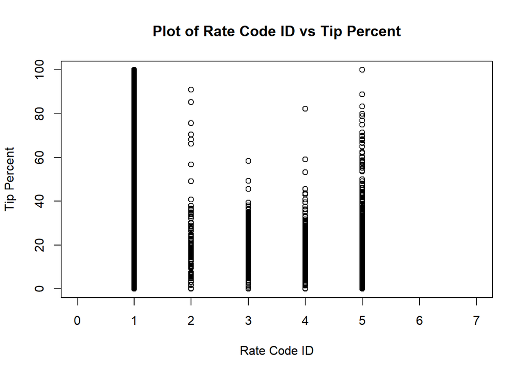

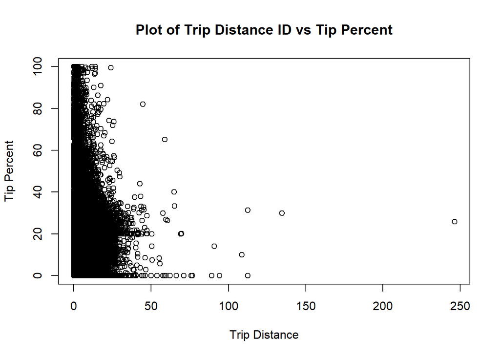

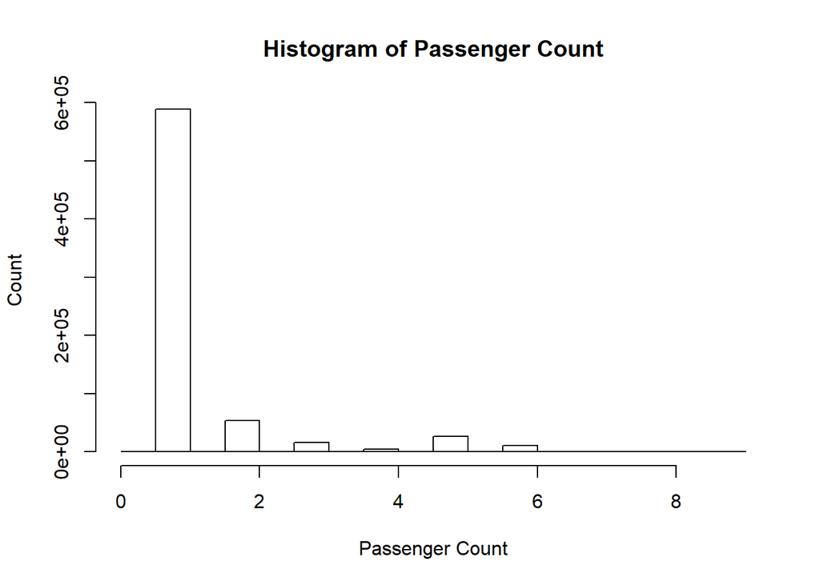

```
##
## Number of transactions with rate code id 4 & greater than 6:  473
```

```
##
## Number of transactions with rate code id 4 & greater than 6 who tip:  392
```

```
##
## Number of transactions with more than 6 passengers:  36
```

```
##
## Number of transactions with more than 6 passengers who tip:  8
```

As part of feature engineering, the below fields are derived:

- trip_duration - difference of drop-off and pick-up times in minutes
- dayOfWeek - of the trip
- dayOfMonth - of the trip
- hour - of the trip
- speed - of the trip in miles per hour

The below filters are applied on derived variables:

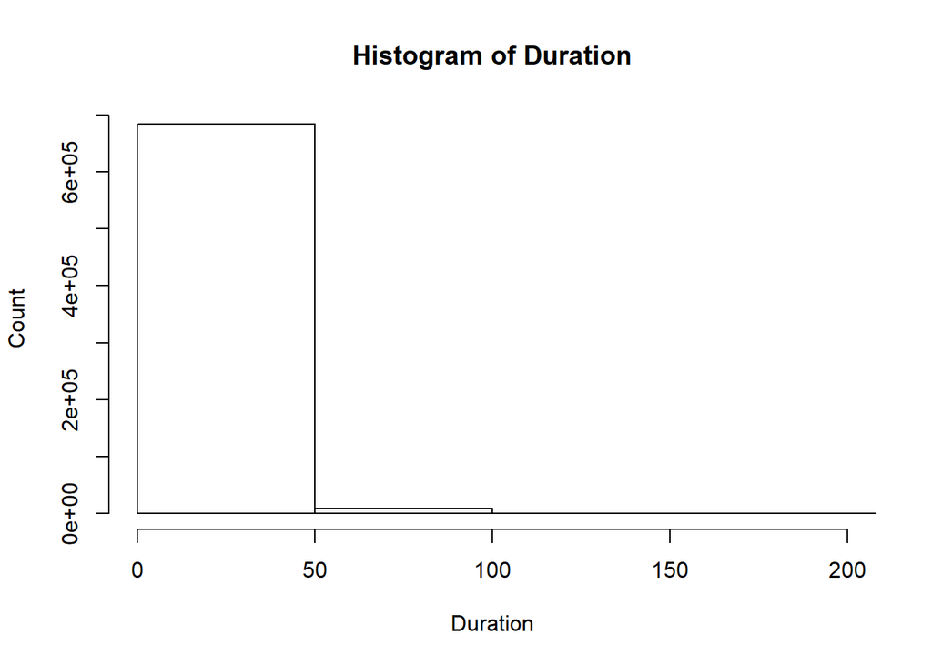

```
##
## Number of transactions with duration greater than 200 miles:  3556
```

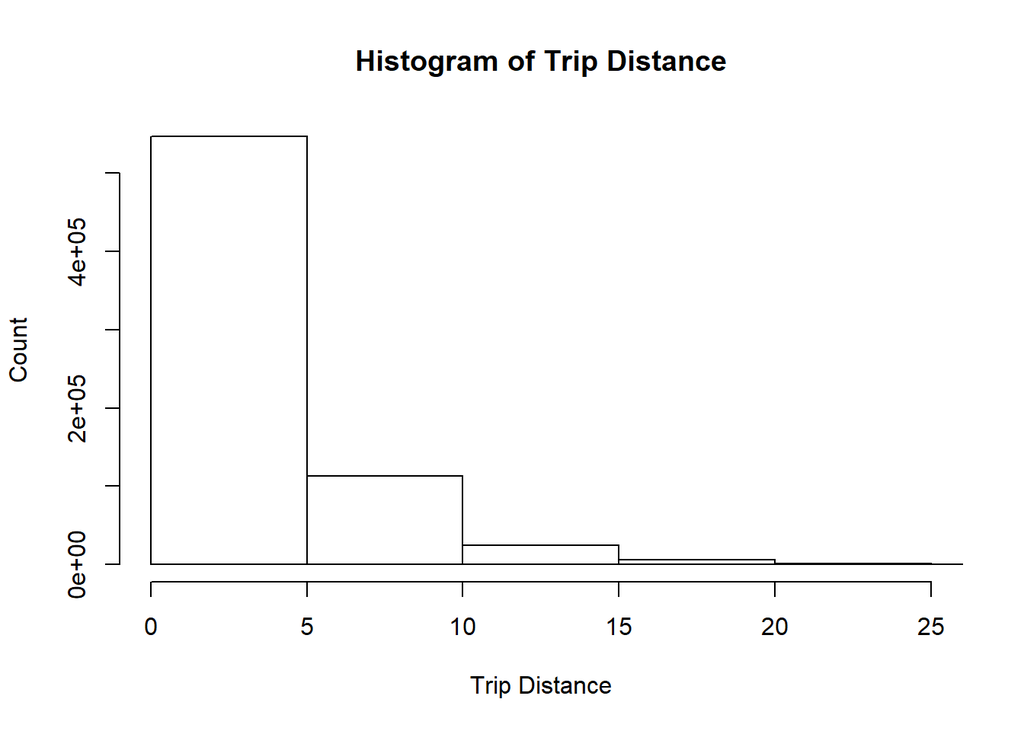

[output not shown]

**Building the model:**

Now that data cleansing and engineering is complete, I begin to test the data for linearity.

The scatter plot of tip_percent against rate code id, trip distance and payment type (displayed during data analysis), show that the independent and the dependent variables are not linearly related. Histogram of explanatory variables - payment_type, trip_distance and amount fields show the data points to be log linearly distributed.

To confirm linear regression model doesn’t fit, I rum lm function on the features and determine the value of r-squared to be 0.04, which is too low for accuracy prediction.

**Code** for making predictions (logistic and loglinear) is provided in the rmd file along with instructions to run at the top of this file.

```
##
## Call:
## lm(formula = percTip ~ VendorID + RateCodeID + Pickup_longitude +
##     Pickup_latitude + Dropoff_longitude + Dropoff_latitude +
##     Passenger_count + Trip_distance + Fare_amount + Extra + MTA_tax +
##     Tolls_amount + improvement_surcharge + duration + Speed +
##     day + hour + dayOfWeek + Trip_type, data = modelData)
##
## Residuals:
##     Min      1Q  Median      3Q     Max
## -85.939  -4.914   2.105   4.534  94.455
##
## Coefficients:
##                         Estimate Std. Error t value Pr(>|t|)
## (Intercept)           -5.564e+02  2.707e+01 -20.558  < 2e-16 ***
## VendorID              -2.887e-01  2.818e-02 -10.243  < 2e-16 ***
## RateCodeID            -6.060e-01  1.254e-01  -4.834 1.34e-06 ***
## Pickup_longitude      -1.108e+01  3.879e-01 -28.568  < 2e-16 ***
## Pickup_latitude       -9.625e+00  3.442e-01 -27.963  < 2e-16 ***
## Dropoff_longitude     -6.810e+00  3.087e-01 -22.059  < 2e-16 ***
## Dropoff_latitude      -8.852e+00  3.472e-01 -25.496  < 2e-16 ***
## Passenger_count        7.733e-02  1.109e-02   6.976 3.04e-12 ***
## Trip_distance         -4.866e-02  1.146e-02  -4.248 2.16e-05 ***
## Fare_amount           -1.734e-02  3.039e-03  -5.706 1.15e-08 ***
## Extra                  1.231e+00  3.337e-02  36.898  < 2e-16 ***
## MTA_tax                9.496e+00  1.015e+00   9.355  < 2e-16 ***
## Tolls_amount           8.326e-01  1.202e-02  69.262  < 2e-16 ***
## improvement_surcharge  2.397e+00  1.514e+00   1.584  0.11322
## duration              -6.042e-02  2.376e-03 -25.431  < 2e-16 ***
## Speed                  8.554e-03  3.036e-03   2.817  0.00485 **
## day                    1.089e-02  1.355e-03   8.038 9.18e-16 ***
## hour                   2.056e-02  1.742e-03  11.801  < 2e-16 ***
## dayOfWeek             -1.278e-02  5.642e-03  -2.265  0.02348 *
## Trip_type             -1.888e-01  6.338e-01  -0.298  0.76583
## ---
## Signif. codes:  0 '***' 0.001 '**' 0.01 '*' 0.05 '.' 0.1 ' ' 1
##
## Residual standard error: 9.522 on 691754 degrees of freedom
## Multiple R-squared:  0.045,  Adjusted R-squared:  0.04497
## F-statistic:  1715 on 19 and 691754 DF,  p-value: < 2.2e-16
```

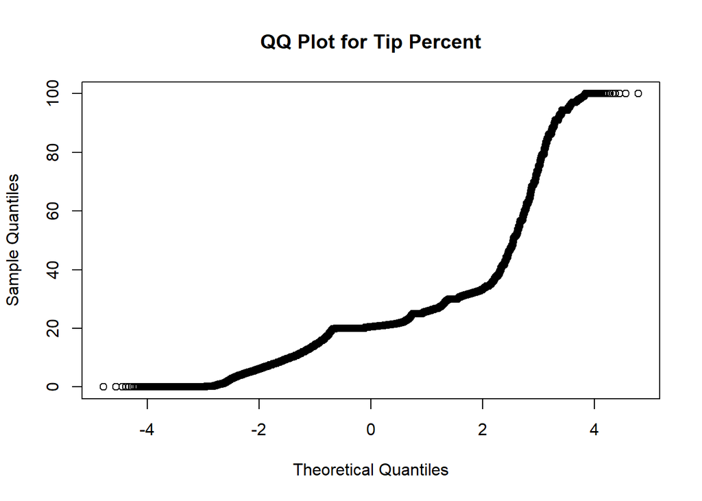

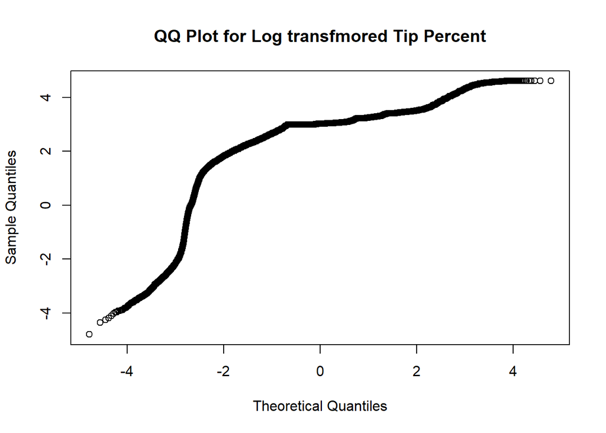

Conditional Probability is used to determine the final tip percent:

P(A) = P(A|B) * P(B)

where,

P(A|B) - tip percent given the customer tips

P(B) - customer tips

**Logistic Model**

```
##
## Call:
## glm(formula = willTip ~ VendorID + RateCodeID + Pickup_longitude +
##     Pickup_latitude + Dropoff_longitude + Dropoff_latitude +
##     Passenger_count + Trip_distance + Fare_amount + Extra + MTA_tax +
##     Tolls_amount + improvement_surcharge + duration + Speed +
##     day + hour + dayOfWeek + Trip_type, family = binomial(link = "logit"),
##     data = train)
##
## Deviance Residuals:
##     Min       1Q   Median       3Q      Max
## -3.8887   0.3937   0.4721   0.5725   2.2060
##
## Coefficients:
##                         Estimate Std. Error z value Pr(>|z|)
## (Intercept)           -4.322e+02  8.156e+00 -52.989  < 2e-16 ***
## VendorID              -3.285e-01  1.075e-02 -30.568  < 2e-16 ***
## RateCodeID            -1.554e-01  3.497e-02  -4.444 8.85e-06 ***
## Pickup_longitude      -2.948e+00  1.341e-01 -21.989  < 2e-16 ***
## Pickup_latitude       -1.670e+00  1.288e-01 -12.968  < 2e-16 ***
## Dropoff_longitude     -5.326e+00  1.108e-01 -48.053  < 2e-16 ***
## Dropoff_latitude      -2.730e+00  1.286e-01 -21.226  < 2e-16 ***
## Passenger_count        2.513e-02  3.949e-03   6.364 1.97e-10 ***
## Trip_distance          3.741e-02  3.580e-03  10.450  < 2e-16 ***
## Fare_amount            1.278e-04  7.651e-04   0.167   0.8673
## Extra                 -5.033e-02  1.158e-02  -4.345 1.39e-05 ***
## MTA_tax                2.746e+00  3.427e-01   8.014 1.11e-15 ***
## Tolls_amount           5.848e-02  4.965e-03  11.778  < 2e-16 ***
## improvement_surcharge  5.000e-01  4.909e-01   1.018   0.3085
## duration              -3.277e-03  7.495e-04  -4.373 1.23e-05 ***
## Speed                  1.229e-02  9.194e-04  13.370  < 2e-16 ***
## day                    4.632e-03  4.726e-04   9.800  < 2e-16 ***
## hour                   8.311e-03  6.103e-04  13.619  < 2e-16 ***
## dayOfWeek             -3.851e-03  1.995e-03  -1.931   0.0535 .
## Trip_type              3.471e-01  2.015e-01   1.723   0.0849 .
## ---
## Signif. codes:  0 '***' 0.001 '**' 0.01 '*' 0.05 '.' 0.1 ' ' 1
##
## (Dispersion parameter for binomial family taken to be 1)
##
##     Null deviance: 444559  on 553418  degrees of freedom
## Residual deviance: 420384  on 553399  degrees of freedom
## AIC: 420424
##
## Number of Fisher Scoring iterations: 5
```

```
## Start:  AIC=420423.8
## willTip ~ VendorID + RateCodeID + Pickup_longitude + Pickup_latitude +
##     Dropoff_longitude + Dropoff_latitude + Passenger_count +
##     Trip_distance + Fare_amount + Extra + MTA_tax + Tolls_amount +
##     improvement_surcharge + duration + Speed + day + hour + dayOfWeek +
##     Trip_type
##
##                         Df Deviance    AIC
## - Fare_amount            1   420384 420422
## - improvement_surcharge  1   420385 420423
## <none>                       420384 420424
## - Trip_type              1   420387 420425
## - dayOfWeek              1   420388 420426
## - duration               1   420403 420441
## - Extra                  1   420403 420441
## - RateCodeID             1   420403 420441
## - Passenger_count        1   420425 420463
## - MTA_tax                1   420443 420481
## - day                    1   420480 420518
## - Trip_distance          1   420491 420529
## - Tolls_amount           1   420533 420571
## - Pickup_latitude        1   420552 420590
## - Speed                  1   420568 420606
## - hour                   1   420568 420606
## - Dropoff_latitude       1   420829 420867
## - Pickup_longitude       1   420859 420897
## - VendorID               1   421367 421405
## - Dropoff_longitude      1   422687 422725
##
## Step:  AIC=420421.8
## willTip ~ VendorID + RateCodeID + Pickup_longitude + Pickup_latitude +
##     Dropoff_longitude + Dropoff_latitude + Passenger_count +
##     Trip_distance + Extra + MTA_tax + Tolls_amount + improvement_surcharge +
##     duration + Speed + day + hour + dayOfWeek + Trip_type
##
##                         Df Deviance    AIC
## - improvement_surcharge  1   420385 420421
## <none>                       420384 420422
## - Trip_type              1   420387 420423
## - dayOfWeek              1   420388 420424
```

[output cut: 57 more lines]

```
## - RateCodeID             1   420405 420437
## - Extra                  1   420406 420438
## - duration               1   420406 420438
## - Passenger_count        1   420428 420460
## - MTA_tax                1   420467 420499
## - day                    1   420483 420515
## - Trip_distance          1   420521 420553
## - Tolls_amount           1   420534 420566
## - Pickup_latitude        1   420556 420588
## - hour                   1   420571 420603
## - Speed                  1   420572 420604
## - Dropoff_latitude       1   420832 420864
## - Pickup_longitude       1   420864 420896
## - VendorID               1   421368 421400
## - Dropoff_longitude      1   422688 422720
```

```
##
## Call:  glm(formula = willTip ~ VendorID + RateCodeID + Pickup_longitude +
##     Pickup_latitude + Dropoff_longitude + Dropoff_latitude +
##     Passenger_count + Trip_distance + Extra + MTA_tax + Tolls_amount +
##     duration + Speed + day + hour + dayOfWeek, family = binomial(link = "logit"),
##     data = train)
##
## Coefficients:
##       (Intercept)           VendorID         RateCodeID
##        -4.315e+02         -3.279e-01         -1.448e-01
##  Pickup_longitude    Pickup_latitude  Dropoff_longitude
##        -2.953e+00         -1.670e+00         -5.321e+00
##  Dropoff_latitude    Passenger_count      Trip_distance
##        -2.729e+00          2.515e-02          3.740e-02
##             Extra            MTA_tax       Tolls_amount
##        -5.043e-02          2.440e+00          5.785e-02
##          duration              Speed                day
##        -3.189e-03          1.232e-02          4.632e-03
##              hour          dayOfWeek
##         8.307e-03         -3.846e-03
##
## Degrees of Freedom: 553418 Total (i.e. Null);  553402 Residual
## Null Deviance:       444600
## Residual Deviance: 420400    AIC: 420400
```

```
##
## Call:
## glm(formula = willTip ~ VendorID + RateCodeID + Pickup_longitude +
##     Pickup_latitude + Dropoff_longitude + Dropoff_latitude +
##     Passenger_count + Trip_distance + Extra + MTA_tax + Tolls_amount +
##     duration + Speed + day + hour, family = binomial(link = "logit"),
##     data = train)
##
## Deviance Residuals:
##     Min       1Q   Median       3Q      Max
## -3.8780   0.3937   0.4721   0.5725   2.2134
##
## Coefficients:
##                     Estimate Std. Error z value Pr(>|z|)
## (Intercept)       -4.317e+02  8.144e+00 -53.003  < 2e-16 ***
## VendorID          -3.278e-01  1.074e-02 -30.533  < 2e-16 ***
## RateCodeID        -1.447e-01  3.377e-02  -4.286 1.82e-05 ***
## Pickup_longitude  -2.950e+00  1.340e-01 -22.015  < 2e-16 ***
## Pickup_latitude   -1.670e+00  1.287e-01 -12.979  < 2e-16 ***
## Dropoff_longitude -5.325e+00  1.108e-01 -48.068  < 2e-16 ***
## Dropoff_latitude  -2.728e+00  1.286e-01 -21.211  < 2e-16 ***
## Passenger_count    2.514e-02  3.949e-03   6.367 1.93e-10 ***
## Trip_distance      3.748e-02  3.187e-03  11.760  < 2e-16 ***
## Extra             -5.055e-02  1.158e-02  -4.365 1.27e-05 ***
## MTA_tax            2.441e+00  2.700e-01   9.039  < 2e-16 ***
## Tolls_amount       5.777e-02  4.941e-03  11.693  < 2e-16 ***
## duration          -3.224e-03  7.192e-04  -4.483 7.37e-06 ***
## Speed              1.237e-02  9.178e-04  13.479  < 2e-16 ***
## day                4.706e-03  4.710e-04   9.993  < 2e-16 ***
## hour               8.256e-03  6.097e-04  13.540  < 2e-16 ***
## ---
## Signif. codes:  0 '***' 0.001 '**' 0.01 '*' 0.05 '.' 0.1 ' ' 1
##
## (Dispersion parameter for binomial family taken to be 1)
##
##     Null deviance: 444559  on 553418  degrees of freedom
## Residual deviance: 420390  on 553403  degrees of freedom
## AIC: 420422
##
## Number of Fisher Scoring iterations: 5
```

**Log Linear Model:**

```
##
## Call:
## glm(formula = percTip ~ VendorID + RateCodeID + Pickup_longitude +
##     Pickup_latitude + Dropoff_longitude + Dropoff_latitude +
##     Passenger_count + Trip_distance + Fare_amount + Extra + MTA_tax +
##     Tolls_amount + duration + Speed + Trip_type, family = gaussian(link = "log"),
##     data = trainlm)
##
## Deviance Residuals:
##     Min       1Q   Median       3Q      Max
## -70.063   -1.712   -0.095    2.738   87.289
##
## Coefficients:
##                     Estimate Std. Error t value Pr(>|t|)
## (Intercept)       41.3103335  1.1785815  35.051  < 2e-16 ***
## VendorID           0.0235804  0.0012024  19.610  < 2e-16 ***
## RateCodeID         0.0109933  0.0060566   1.815 0.069511 .
## Pickup_longitude  -0.0940595  0.0174193  -5.400 6.68e-08 ***
## Pickup_latitude   -0.3983760  0.0157181 -25.345  < 2e-16 ***
## Dropoff_longitude  0.3299460  0.0140980  23.404  < 2e-16 ***
## Dropoff_latitude  -0.1146157  0.0159341  -7.193 6.34e-13 ***
## Passenger_count    0.0012269  0.0004666   2.629 0.008552 **
## Trip_distance     -0.0020683  0.0006754  -3.062 0.002198 **
## Fare_amount       -0.0019959  0.0002244  -8.895  < 2e-16 ***
## Extra              0.0763121  0.0013517  56.457  < 2e-16 ***
## MTA_tax            0.1581345  0.0462859   3.416 0.000634 ***
## Tolls_amount       0.0379755  0.0004312  88.069  < 2e-16 ***
## duration          -0.0043591  0.0001395 -31.241  < 2e-16 ***
## Speed             -0.0024584  0.0001558 -15.783  < 2e-16 ***
## Trip_type          0.0201636  0.0222348   0.907 0.364487
## ---
## Signif. codes:  0 '***' 0.001 '**' 0.01 '*' 0.05 '.' 0.1 ' ' 1
##
## (Dispersion parameter for gaussian family taken to be 48.6655)
##
##     Null deviance: 24543157  on 476946  degrees of freedom
## Residual deviance: 23209959  on 476931  degrees of freedom
## AIC: 3206457
##
## Number of Fisher Scoring iterations: 6
```

```
## Start:  AIC=3206457
## percTip ~ VendorID + RateCodeID + Pickup_longitude + Pickup_latitude +
##     Dropoff_longitude + Dropoff_latitude + Passenger_count +
##     Trip_distance + Fare_amount + Extra + MTA_tax + Tolls_amount +
##     duration + Speed + Trip_type
##
##                     Df Deviance     AIC
## - Trip_type          1 23210000 3206456
## <none>                 23209959 3206457
## - RateCodeID         1 23210124 3206459
## - Passenger_count    1 23210294 3206462
## - Trip_distance      1 23210334 3206463
## - MTA_tax            1 23210546 3206467
## - Pickup_longitude   1 23211356 3206484
## - Dropoff_latitude   1 23212459 3206507
## - Fare_amount        1 23214142 3206541
## - Speed              1 23221489 3206692
## - VendorID           1 23228912 3206845
## - Dropoff_longitude  1 23236062 3206991
## - Pickup_latitude    1 23240957 3207092
## - duration           1 23246038 3207196
## - Extra              1 23363622 3209603
## - Tolls_amount       1 23509024 3212562
##
## Step:  AIC=3206456
## percTip ~ VendorID + RateCodeID + Pickup_longitude + Pickup_latitude +
##     Dropoff_longitude + Dropoff_latitude + Passenger_count +
##     Trip_distance + Fare_amount + Extra + MTA_tax + Tolls_amount +
##     duration + Speed
##
##                     Df Deviance     AIC
## <none>                 23210000 3206456
## + Trip_type          1 23209959 3206457
## - RateCodeID         1 23210318 3206461
## - Passenger_count    1 23210335 3206461
## - Trip_distance      1 23210382 3206462
## - MTA_tax            1 23210560 3206466
## - Pickup_longitude   1 23211404 3206483
## - Dropoff_latitude   1 23212474 3206505
## - Fare_amount        1 23214249 3206541
## - Speed              1 23221492 3206690
## - VendorID           1 23228967 3206844
## - Dropoff_longitude  1 23236252 3206993
## - Pickup_latitude    1 23241132 3207093
## - duration           1 23246467 3207203
## - Extra              1 23363634 3209601
## - Tolls_amount       1 23514891 3212679
```

```
##
## Call:  glm(formula = percTip ~ VendorID + RateCodeID + Pickup_longitude +
##     Pickup_latitude + Dropoff_longitude + Dropoff_latitude +
##     Passenger_count + Trip_distance + Fare_amount + Extra + MTA_tax +
##     Tolls_amount + duration + Speed, family = gaussian(link = "log"),
##     data = trainlm)
##
## Coefficients:
##       (Intercept)           VendorID         RateCodeID
##         41.356849           0.023588           0.013484
##  Pickup_longitude    Pickup_latitude  Dropoff_longitude
##         -0.094285          -0.398935           0.330534
##  Dropoff_latitude    Passenger_count      Trip_distance
##         -0.113884           0.001227          -0.002091
##       Fare_amount              Extra            MTA_tax
##         -0.002014           0.076303           0.139820
##      Tolls_amount           duration              Speed
##          0.037914          -0.004342          -0.002447
##
## Degrees of Freedom: 476946 Total (i.e. Null);  476932 Residual
## Null Deviance:       24540000
## Residual Deviance: 23210000  AIC: 3206000
```

```
##
## Call:
## glm(formula = percTip ~ VendorID + Pickup_longitude + Pickup_latitude +
##     Dropoff_longitude + Dropoff_latitude + Fare_amount + Tolls_amount +
##     duration + Speed, family = gaussian(link = "log"), data = trainlm)
##
## Deviance Residuals:
##     Min       1Q   Median       3Q      Max
## -68.567   -2.195    0.007    2.641   87.520
##
## Coefficients:
##                     Estimate Std. Error t value Pr(>|t|)
## (Intercept)       45.5122267  1.1755987  38.714  < 2e-16 ***
## VendorID           0.0246817  0.0012009  20.552  < 2e-16 ***
## Pickup_longitude  -0.0866297  0.0173038  -5.006 5.55e-07 ***
## Pickup_latitude   -0.4060617  0.0156128 -26.008  < 2e-16 ***
## Dropoff_longitude  0.3542768  0.0138024  25.668  < 2e-16 ***
## Dropoff_latitude  -0.1489131  0.0158154  -9.416  < 2e-16 ***
## Fare_amount       -0.0031983  0.0001545 -20.701  < 2e-16 ***
## Tolls_amount       0.0373579  0.0004234  88.233  < 2e-16 ***
## duration          -0.0040663  0.0001250 -32.518  < 2e-16 ***
## Speed             -0.0024435  0.0001153 -21.186  < 2e-16 ***
## ---
## Signif. codes:  0 '***' 0.001 '**' 0.01 '*' 0.05 '.' 0.1 ' ' 1
##
## (Dispersion parameter for gaussian family taken to be 48.99158)
##
##     Null deviance: 24543157  on 476946  degrees of freedom
## Residual deviance: 23365846  on 476937  degrees of freedom
## AIC: 3209638
##
## Number of Fisher Scoring iterations: 6
```

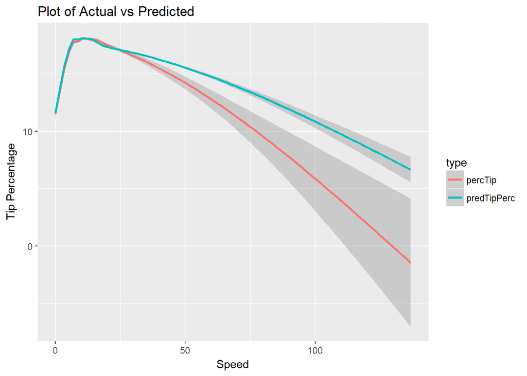

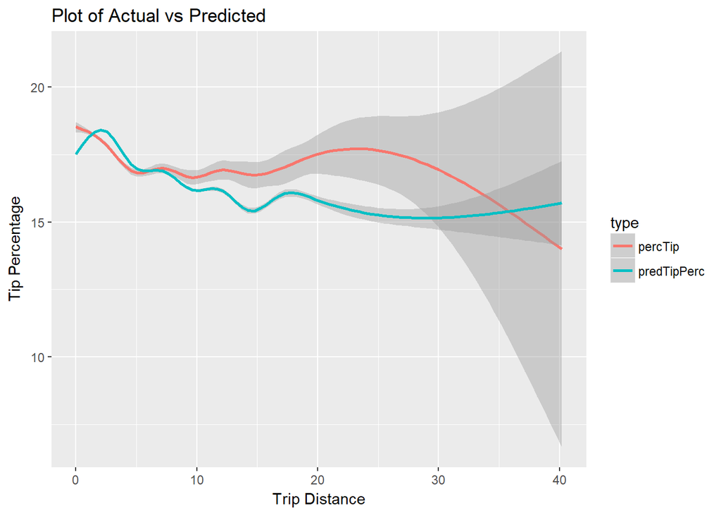

**Future direction:**

As part of future work, I would prefer to do predictions using random forest model with stratified cross validation to achieve a better accuracy. Below is sample execution of random forest and random forest with cross validation.

- The below testing is performed using 1% of random sample cleansed data that is not a good representation of the overall data set.
- Currently, the models are generating a very low r^2 (or) % variance explained. Using a bigger dataset with atleast 10 cross validations, we would be able to achieve a better predictive model.

Also, as the dependent variable is not perfectly normal, it would be a good idea to use a generalized additive model with gamma distribution.

Given more time and better processor, we can also run random forest with cross validation to generate models with higher accuracy.

```
##
## Call:
##  randomForest(formula = percTip ~ VendorID + RateCodeID + Pickup_longitude +      Pickup_latitude + Dropoff_longitude + Dropoff_latitude +      Passenger_count + Trip_distance + Fare_amount + Extra + MTA_tax +      Tolls_amount + improvement_surcharge + duration + Speed +      day + hour + dayOfW…
##                Type of random forest: regression
##                      Number of trees: 250
## No. of variables tried at each split: 6
##
##           Mean of squared residuals: 88.52365
##                     % Var explained: 7.49
```

```
##            used  (Mb) gc trigger   (Mb)  max used   (Mb)
## Ncells  3723654 198.9    6861544  366.5   6861544  366.5
## Vcells 81119541 618.9  270045065 2060.3 337539465 2575.3
```

```
## Random Forest
##
## 6917 samples
##   18 predictor
##
## No pre-processing
## Resampling: Cross-Validated (5 fold)
## Summary of sample sizes: 5534, 5533, 5532, 5535, 5534
## Resampling results across tuning parameters:
##
##   mtry  RMSE      Rsquared    MAE
##    2    9.396208  0.07673230  6.937509
##   10    9.462128  0.07054979  6.995045
##   18    9.493197  0.06767893  7.023920
##
## RMSE was used to select the optimal model using the smallest value.
## The final value used for the model was mtry = 2.
```

```
##            used  (Mb) gc trigger   (Mb)  max used   (Mb)
## Ncells  3734141 199.5    6861544  366.5   6861544  366.5
## Vcells 64300888 490.6  172828841 1318.6 337539465 2575.3
```

# Question 5 - Distribution - Average Speed

Now I derive Speed, distance (trip_distance) by time (trip_duration), a new explanatory variable for analysis.

The derived variable has nearly 4000 records as NA’s or infinite. This is associated to most of the trips having 0 trip distance. Speed also has a maximum value of 2000 mph.

Using google search, I found the maximum speed limit in New York City to be 50 mph and in United States to be 137 mph. And so, data is cleansed to include records having Speed within 140 miles per hour.

| speedSubset$week | speedSubset$Speed |
| --- | --- |
| 1 | 13.46063 |
| 2 | 12.47781 |
| 3 | 12.54530 |
| 4 | 13.15193 |
| 5 | 12.19162 |

| speedSubset$week | speedSubset$Speed |
| --- | --- |
| 1 | 6.406365 |
| 2 | 6.112889 |
| 3 | 6.074027 |
| 4 | 6.298078 |
| 5 | 5.882751 |

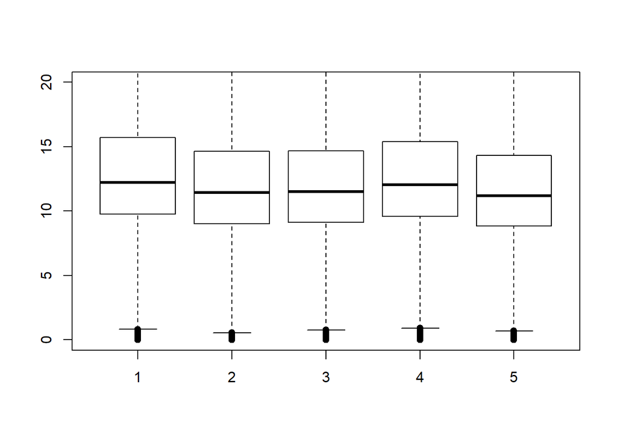

**Analyzing** :

If the average trip speeds are materially the same in all weeks of September.

**Test Used:**

I have used ANOVA test with the null hypothesis that the average trip speeds are same in all weeks.

```
##                       Df   Sum Sq Mean Sq F value Pr(>F)
## speedSubset$week       1    39237   39237    1016 <2e-16 ***
## Residuals        1491223 57571674      39
## ---
## Signif. codes:  0 '***' 0.001 '**' 0.01 '*' 0.05 '.' 0.1 ' ' 1
```

```
##
##
## t.test(Speed[week ==  1 ], Speed[week ==  2 ])
##
##
##  Welch Two Sample t-test
##
## data:  x and y
## t = 65.639, df = 693560, p-value < 2.2e-16
## alternative hypothesis: true difference in means is not equal to 0
## 95 percent confidence interval:
##  0.9534768 1.0121708
## sample estimates:
## mean of x mean of y
##  13.46063  12.47781
##
##
##
## t.test(Speed[week ==  1 ], Speed[week ==  3 ])
##
##
##  Welch Two Sample t-test
##
## data:  x and y
## t = 61.391, df = 693780, p-value < 2.2e-16
## alternative hypothesis: true difference in means is not equal to 0
## 95 percent confidence interval:
##  0.8861069 0.9445526
## sample estimates:
## mean of x mean of y
##  13.46063  12.54530
##
##
##
## t.test(Speed[week ==  1 ], Speed[week ==  4 ])
##
##
##  Welch Two Sample t-test
##
## data:  x and y
```

[output cut: 104 more lines]

```
##
##
## t.test(Speed[week ==  4 ], Speed[week ==  5 ])
##
##
##  Welch Two Sample t-test
##
## data:  x and y
## t = 42.874, df = 149770, p-value < 2.2e-16
## alternative hypothesis: true difference in means is not equal to 0
## 95 percent confidence interval:
##  0.9164146 1.0042157
## sample estimates:
## mean of x mean of y
##  13.15193  12.19162
```

The p-value of the ANOVA test is very small and close to 0. Thus, the null hypothesis is rejected - the average trip speeds are not same in all weeks.

A 2-sample t-test, with significance value set at 0.05, is performed on all the weeks, to check if the means are same between any two weeks, but the p-vale is again close to 0 for all t-tests and no two weeks have the same means.

My hypothesis for average speed variation (based on the boxplot) is below:

- Week 1 - Includes the Labor Day (September 7) long weekend. People would be entering or leaving the city for vacation on different dates. There would be less than normal traffic on these dates causing the average speed to be higher comparatively.
- Week 2 - People would be returning or leaving from vacation after the long weekend, causing traffic jam on Tuesday, whereby reducing the average speed of the week
- Week 3 - Most of the people would have returned to their daily routine and few people would still be returning from a long vacation, average speed of the week would be returning to normal
- Week 4 - People would have returned to their daily routines and traffic would be less as daily commuters in NYC tend to take public transports and so the average speed is more compared to previous weeks. This would be a good approximate of the average speed of the week
- Week 5 - Has only two days with peak Monday traffic which is why the average traffic is more.

To analyze, if the average trip speeds are same in the hours of day, I have used ANOVA test with the null hypothesis that the average trip speeds are same in all hours.

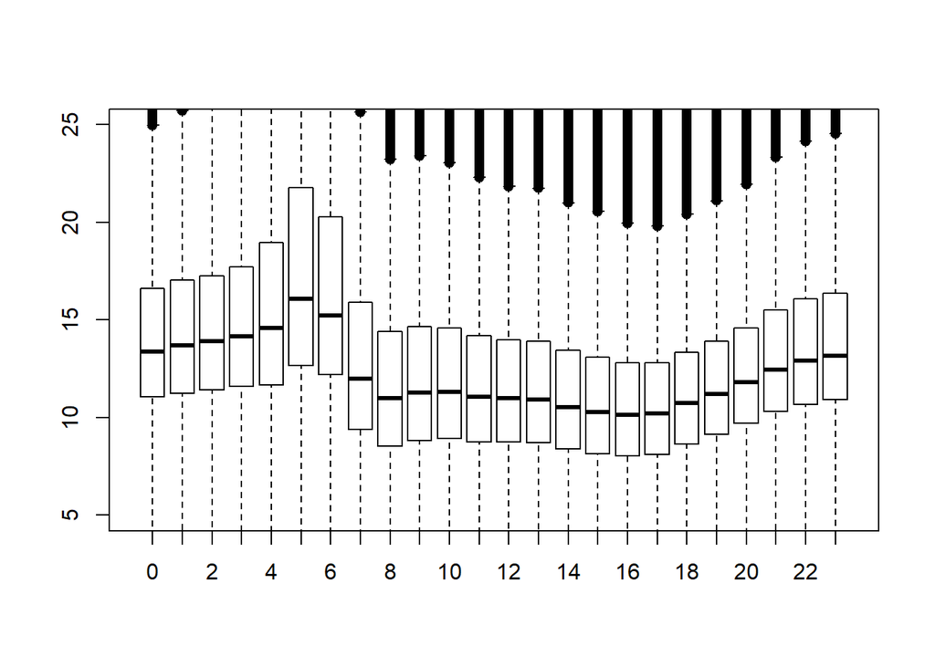

```
##                       Df   Sum Sq Mean Sq F value Pr(>F)
## speedSubset$hour       1   611985  611985   16011 <2e-16 ***
## Residuals        1491223 56998926      38
## ---
## Signif. codes:  0 '***' 0.001 '**' 0.01 '*' 0.05 '.' 0.1 ' ' 1
```

```
##
##
## t.test(Speed[hour ==  0 ], Speed[hour ==  1 ])
##
##
##  Welch Two Sample t-test
##
## data:  x and y
## t = -6.6388, df = 113400, p-value = 3.177e-11
## alternative hypothesis: true difference in means is not equal to 0
## 95 percent confidence interval:
##  -0.3219430 -0.1751774
## sample estimates:
## mean of x mean of y
##  14.56728  14.81584
##
##
##
## t.test(Speed[hour ==  0 ], Speed[hour ==  2 ])
##
##
##  Welch Two Sample t-test
##
## data:  x and y
## t = -10.62, df = 85070, p-value < 2.2e-16
## alternative hypothesis: true difference in means is not equal to 0
## 95 percent confidence interval:
##  -0.5097389 -0.3509069
## sample estimates:
## mean of x mean of y
##  14.56728  14.99760
##
##
##
## t.test(Speed[hour ==  0 ], Speed[hour ==  3 ])
##
##
##  Welch Two Sample t-test
##
## data:  x and y
```

[output cut: 4360 more lines]

```
##
##
## t.test(Speed[hour ==  22 ], Speed[hour ==  23 ])
##
##
##  Welch Two Sample t-test
##
## data:  x and y
## t = -9.4107, df = 163050, p-value < 2.2e-16
## alternative hypothesis: true difference in means is not equal to 0
## 95 percent confidence interval:
##  -0.3413100 -0.2236461
## sample estimates:
## mean of x mean of y
##  14.04607  14.32855
```

The p-value of the ANOVA test is very small and close to 0. Thus, the null hypothesis is rejected - the average trip speeds are not same for all hours.

A 2-sample t-test, with significance value set at 0.05, is performed on all the hours, to check if the means are same between any two hours, the results of p-value is given below:

- Hours 8:00 AM and 11:00 AM, 9:00 AM and 10:00 AM have the same mean - p-value is greater than significance value
  - peak hour traffic would be nearly same, people start leaving for office around 7:00 AM and reach around 11:00 AM causing the average to be approximately same between 8:00 AM and 11:00 AM. Thus, the average speed is same.
- Hours 1:00 PM and 7:00 PM, 2:00 PM and 6:00 PM have the same mean - p-value is greater than significance value
  - mid-day traffic and just after office hours traffic would be nearly same as roads would be cleared from morning rush hour (between 7 to 11 AM and evening rush hour 4-5 PM). Thus, the average speed is same.
- Hours 4:00 PM and 5:00 PM have the same mean - p-value is greater than significance value
  - evening peak hour traffic would be nearly same, people start leaving from office around 4:00 PM causing the average speed to be approximately same
- For the remaining combination of hours, p-value is close to 0 and so they don’t have the same means.

My hypothesis for average speed variation (based on the boxplot) is below:

- average speed is increasing continuously from mid-night, 00:00 AM to 5:00 AM, as majority of the people would be home, and the roads would be empty
- average speed dropped at 7:00 AM and continuous nearly the same during the morning peak hours, 7:00 AM to 11:00 AM, as people would be rushing to office
- average speed is fluctuating during mid-day, 10:00 AM to 5:00 PM, schools would close, people will be running errands randomly and would start leaving office
- average speed is increasing slowly after evening peak hours, 6:00 PM to 11:00 PM, as people would have reached home